# Typhoon Fung-Wong (2025): Rapid Report

Lincole Jiang, Victoria D. Lynch, G. Brooke Anderson, Robbie M. Parks

2025-11-17

## Summary

*Typhoon Fung-Wong*, known in the Philippines as Super Typhoon Uwan, was a very large, powerful and destructive tropical cyclone that struck the Philippines, Taiwan, and the Ryukyu Islands of Japan. Based on IBTrACS data from 2025-11-04 06:00:00 to 2025-11-13 UTC, 22,260,904 people experienced tropical cyclone-force (>= 17.49 m/s) winds and 2,821,868 people experienced hurricane-force (>= 32.90 m/s) winds.

Table 1: Population exposed by country and storm intensity

| Country | Population exposed (tropical cyclone-force) | Population exposed (hurricane-force) |
| --- | --- | --- |
| Philippines | 22,217,385 | 2,821,868 |
| Taiwan, Province of China | 43,519 | 0 |

To account for percentage of total population affected, a fifth of the population in the Philippines were affeced by tropical cyclone-force winds.

Table 2: Percentage of total population exposed by country and storm intensity

| Country | % Population exposed (tropical cyclone-force) | % Population exposed (hurricane-force) |
| --- | --- | --- |
| Philippines | 20.1 | 2.6 |
| Taiwan, Province of China | 0.2 | 0.0 |

The spatial extent of the impacts is illustrated in Figure 1, which maps exposure by wind intensity threshold at second administrative unit (ADM2, US county-equivalent) level along with storm track of Fung-Wong.

[figure not shown]

Figure 1: spatial distribution of exposure

## Characterizing exposed areas

Figure 2 shows the distribution of relative deprivation (measured by population-weighted global Gridded Relative Deprivation Index, or GRDI, aggregated to ADM2 level) and population for each exposed area, categorized by exposure status.

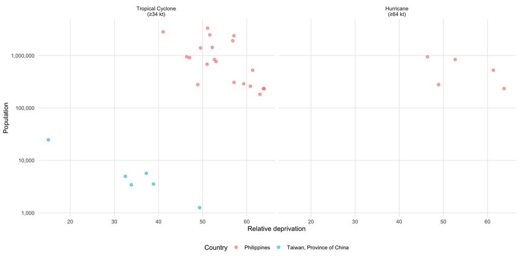

Figure 2: Socioeconomic and population distribution of exposed areas

Furthermore, we list the top areas affected (categorized by exposure status) with the most population:

|  | Area | Country | Population | Deprivation |
| --- | --- | --- | --- | --- |
| 1 | Pangasinan | Philippines | 3,332,975 | High |
| 2 | Pampanga | Philippines | 2,828,363 | Moderately high |
| 3 | Nueva Ecija | Philippines | 2,474,413 | High |
| 4 | Camarines Sur | Philippines | 2,386,755 | High |
| 5 | Isabela | Philippines | 1,912,972 | High |
| 6 | Albay | Philippines | 1,426,572 | High |
| 7 | Tarlac | Philippines | 1,396,855 | High |
| 8 | Benguet | Philippines | 944,982 | Moderately high |
| 9 | Zambales | Philippines | 912,100 | Moderately high |
| 10 | La Union | Philippines | 838,391 | High |

[output cut: 16 more lines]

|  | Area | Country | Population | Deprivation |
| --- | --- | --- | --- | --- |
| 1 | Benguet | Philippines | 944,982 | Moderately high |
| 2 | La Union | Philippines | 838,391 | High |
| 3 | Nueva Vizcaya | Philippines | 525,000 | High |
| 4 | Aurora | Philippines | 279,335 | High |
| 5 | Quirino | Philippines | 234,160 | High |